# Multivariate models for the BPA/BPS vs growth outcomes

SINCE LAST TIME:

- Error on the beta representation, standardisation error
- Parity in 3 cats
- Ultrasound outcomes

TO DISCUSS:

- Model all outcomes even the highly correlated ones? Is it worth presenting biparietal diam and HC?
- which BPA model to choose as main? (BPA, ln(BPA), tertiles…?)
- Outliers: confirm that given the fact that we adjust there is no need to exclude any data from ultrasound and maybe one born at 30 weeks for birth data?
- Bayesian?
- checked tobacco beta which was equal to -471grams for smokers. doesn’t seem to be due to an outlier. but i noticed beta is equal to -471g on data subset with all smoke variables available (N = 391 women) but when computed on all women (N = 457) beta = -259g which is closer to expected. why?? no answer yet
- Which associations should be commented? See my criterion list. Eg in the tertiles model should we dismiss associations with tertile2 only or consider them as non-linear?
- OK to standardise outcomes by dividing by SD?

Data management (talked with Karine):

- Concerning ultrasound data what should I transfer: only the biometrical data or all ultrasound data? (text vars, )
- Should I add labels?
- Also include the manual ultrasounds?
- Should I perform any data cleaning? (outliers, etc)

TO DO:

- Get day 3 HC measure + check Ns and re-run analysis + copmpare birth day measure with D3 measure
- compare results to litterature
- check residuals outliers for T2 and T3 femur length models and head circumference
- Do analysis on raw BPA (not corrected for batch and protocol variables)

Note on head circumference: data currently presented is data from carnet de santé and is measured the day of the exam by the clinic doctors. Another measure is perfomed approx 3 days later for sepages. I don’t have this data yet and according to Sarah there might be up to 50% missing (19/11/19).

# 1 Intro

This document is a first draft to show the model outputs of the analysis “exposure to BPA/BPS during pregnancy vs growth outcomes”.

Included outcomes are:

```
##  [1] "femur_length_T2"            "femur_length_T3"
##  [3] "abdominal_circumference_T2" "abdominal_circumference_T3"
##  [5] "biparietal_diameter_T2"     "biparietal_diameter_T3"
##  [7] "head_circumference_T2"      "head_circumference_T3"
##  [9] "head_circ"                  "birth_length"
## [11] "birth_weight"
```

Measures for the outcome were standardised (division by SD) in order to make the betas comparable between outcomes.

BPA data are the standardised values ie corrected for batch and other protocol vars.

BPS data are presented as detected/undetected due to the relatively small number of samples between LOD and LOQ.

Models presented are

- Main models, with and without interaction between child sex and exposure
  - outcomes ~ untransformed and standardized BPA at T2 and T3
  - outcomes ~ detected/undetected levels of BPS at T2 and T3
- Secondary models, with and without interaction between child sex and exposure
  - outcomes ~ ln transform of standardised BPA at T2 and T3
  - outcomes ~ tertiles of standardised BPA at T2 and T3
  - outcomes ~ geometric mean of BPA
  - outcomes ~ cumulative BPS (detected never, at T2, at T3, at T2 and T3)

Outputs and residuals are presented for the main models only (with and without interaction).

# 2 Visualisation

Here we observe for potential outliers.

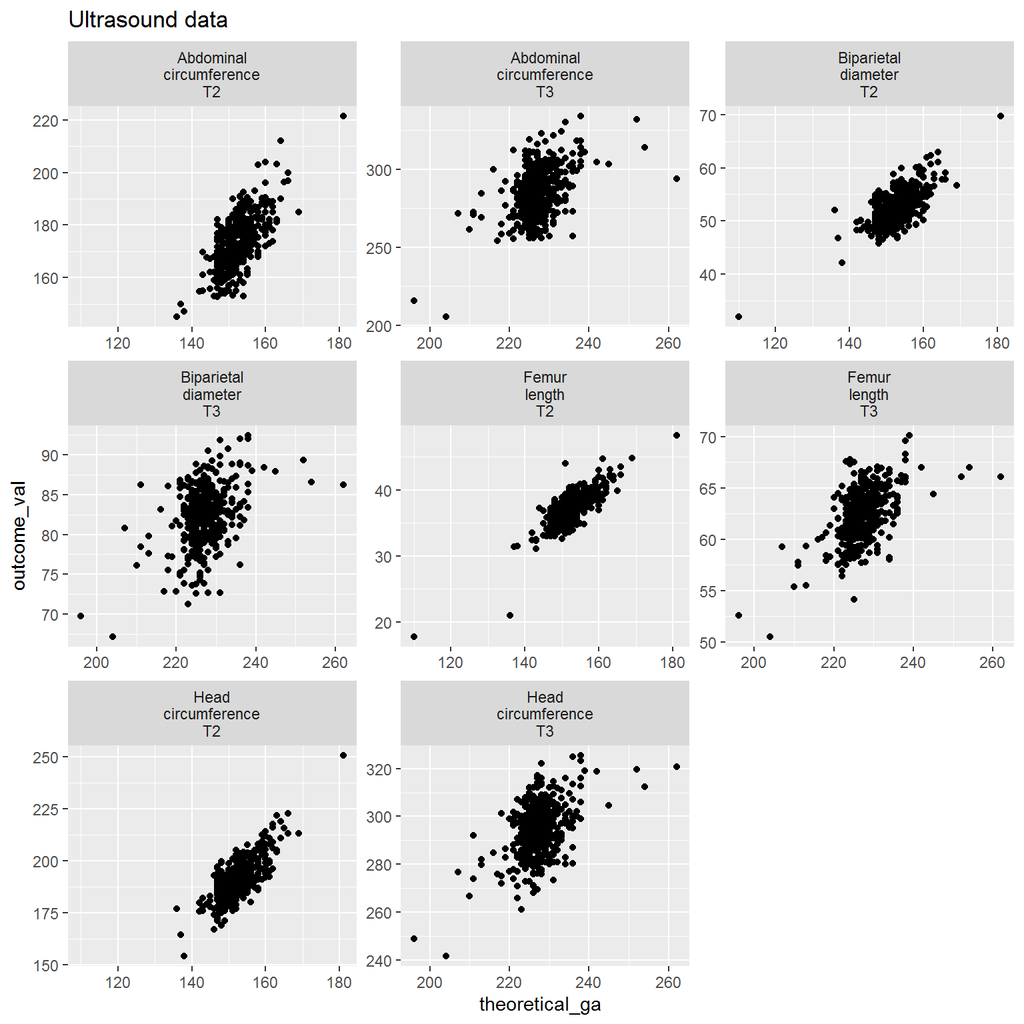

- Given that we are adjusting on **GA + GA^2** I would keep all data (no outliers).

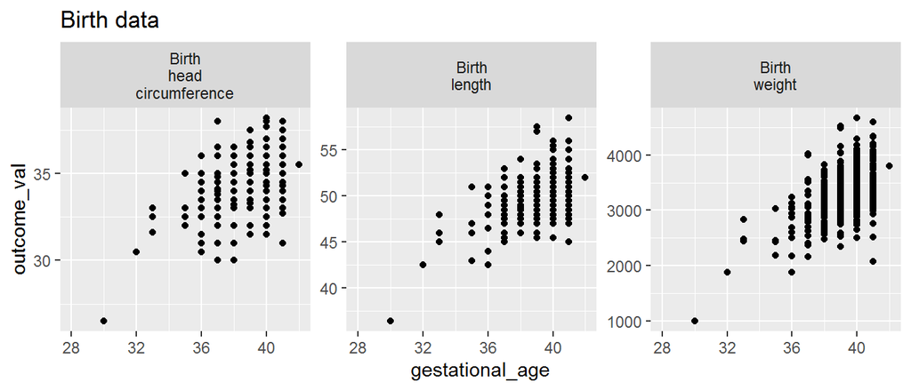

Maybe re-run analysis without baby born at week 30? Or another cutoff?

# 3 Correlation between outcomes

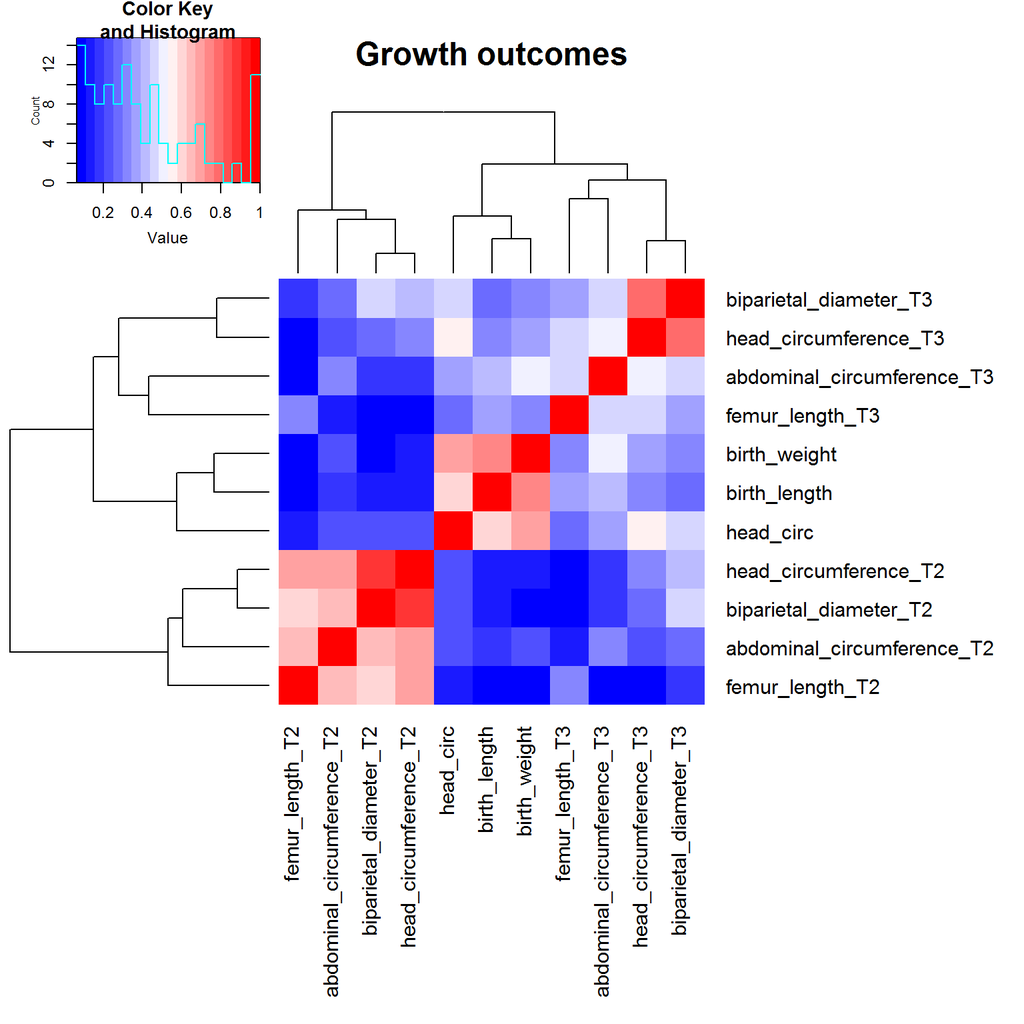

For example correlation between biparietal diameter and head circumference

- 0.89 at T2
- 0.80 at T3

Selecting would reduce number of regressions.

# 4 Main results with interaction on sex

Here I show betas from the interaction model alongside the betas from the models without interaction. **Outcome data are standardised by outcome_val/sd to make betas comparable**.

## 4.1 Summary of main results

Residuals OK (**a couple of outliers to check for T2 and T3 femur length models and head circumference at birth**)

## 4.2 BPA

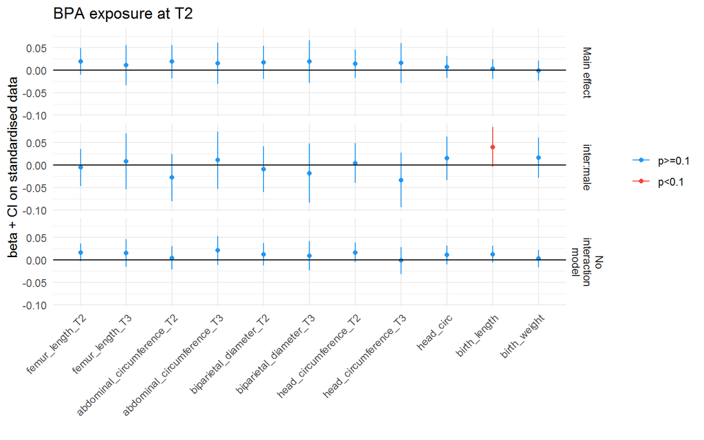

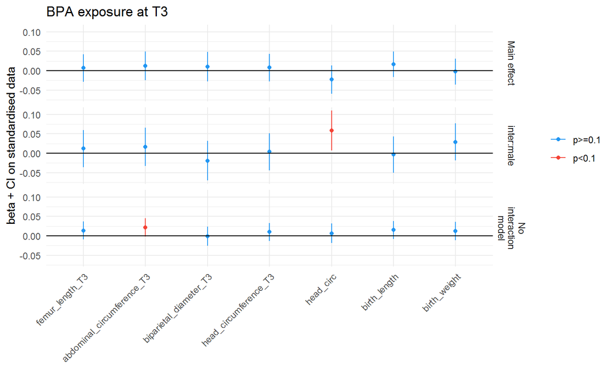

## 4.3 BPS

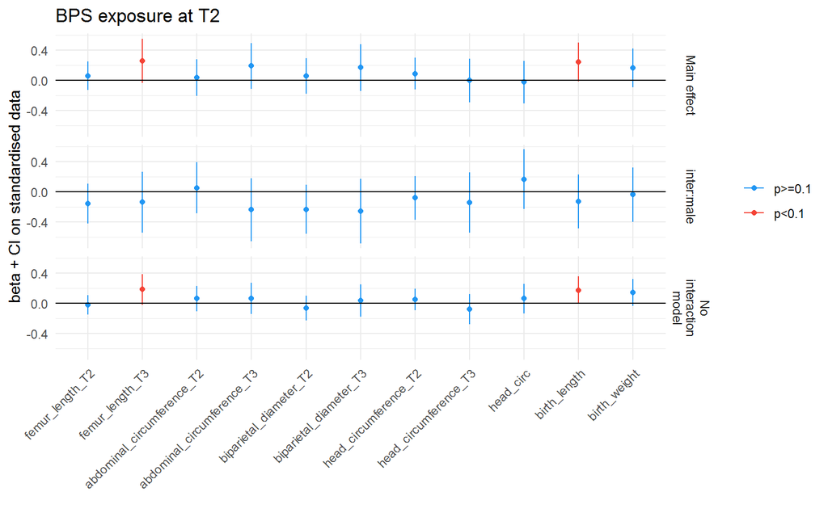

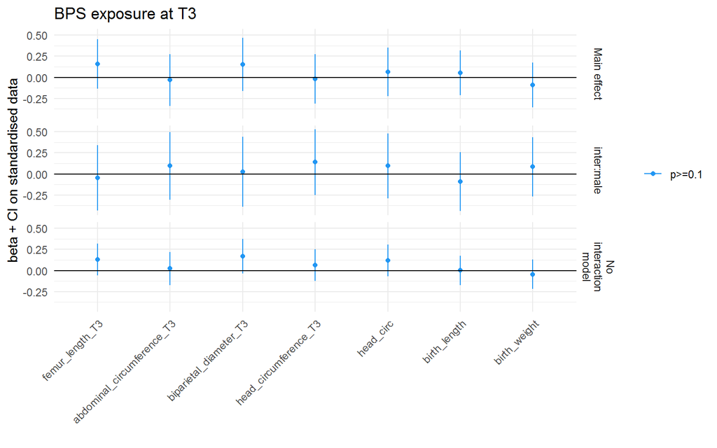

# 5 Secondary results

## 5.1 ln(BPA)

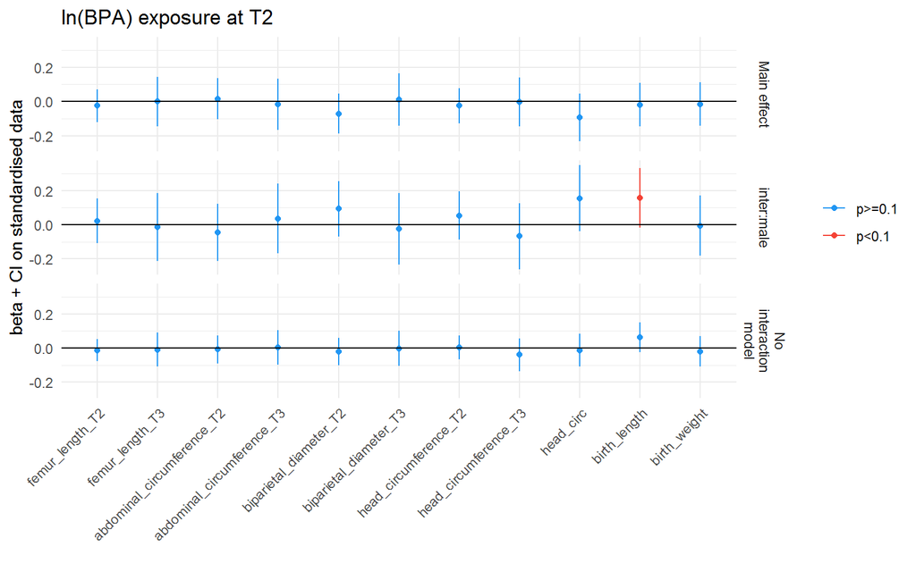

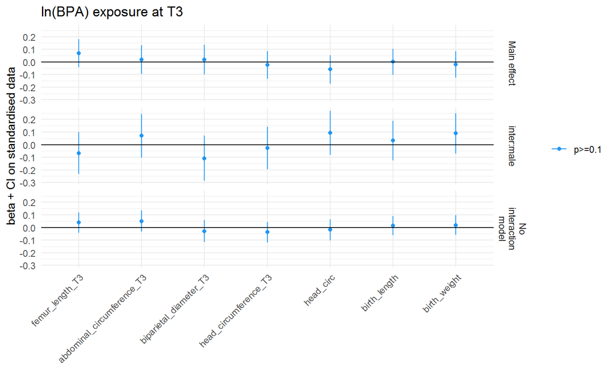

## 5.2 BPA tertiles

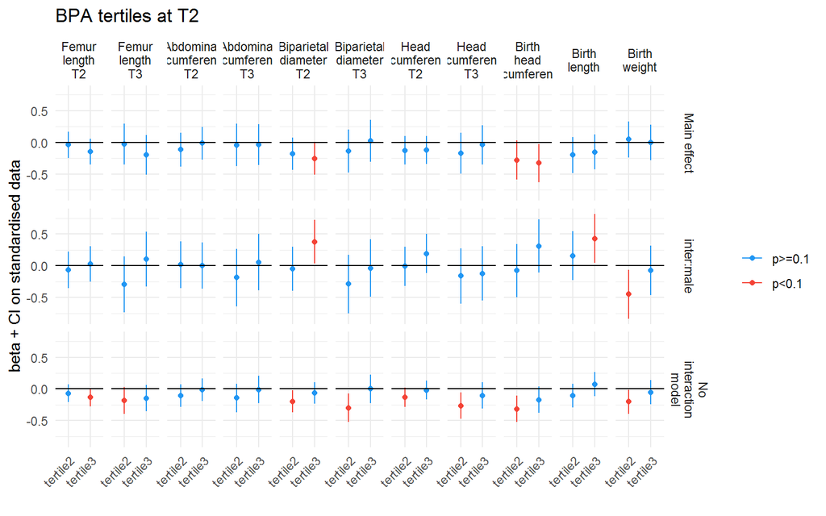

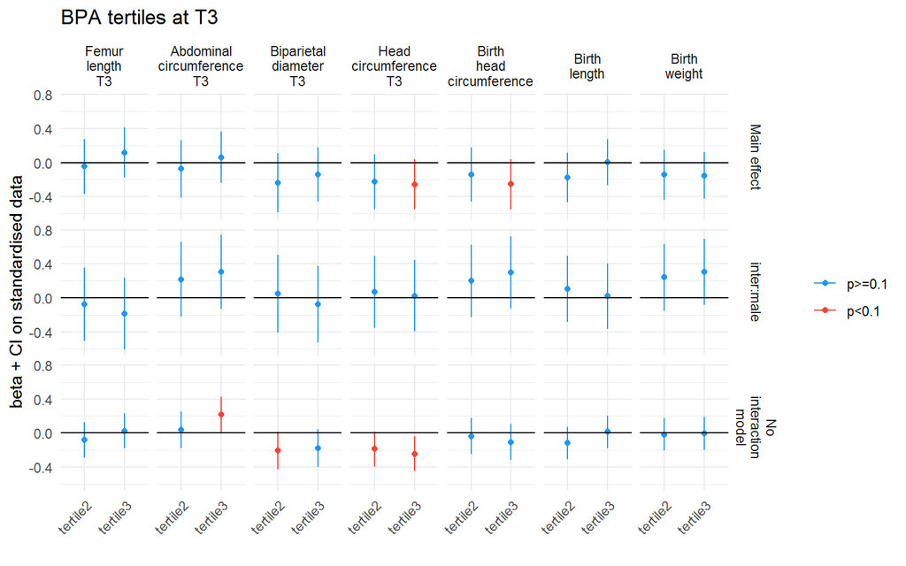

## 5.3 BPA geometric mean

Geometric mean of BPA at T2 and at T3: $\sqrt(BPA_{T2}*BPA_{T3})$

[figure not shown]

## 5.4 BPS cumulative

- no detects
- detected at T2 only
- detected at T3 only
- detected at T2 and T3

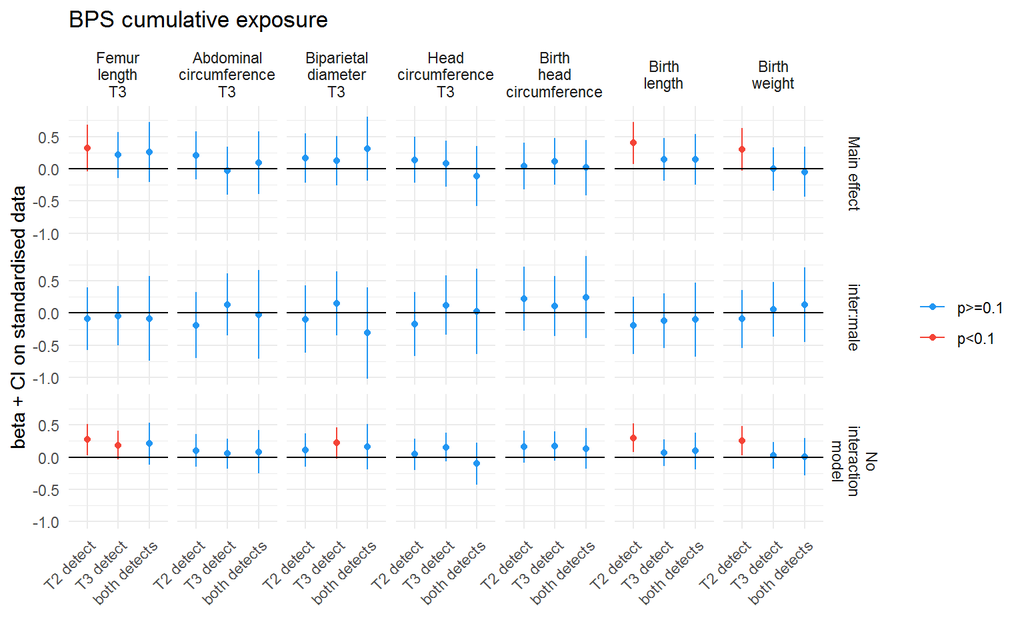

# 6 Main model outputs

## 6.1 BPA

### 6.1.1 No sex interaction

```
## [1] "*******************abdominal_circumference_T2*******************"
## [2] "*******************BPA_T2*******************"
##
## Call:
## lm(formula = outcome_val_sd ~ exp_val + child_sex + mom_age +
##     mom_weight + mom_height + gestational_age + I(gestational_age^2) +
##     mom_edu + parity + smoke_high_t2, data = .x)
##
## Residuals:
##      Min       1Q   Median       3Q      Max
## -1.84662 -0.43912 -0.04676  0.45384  2.05851
##
## Coefficients:
##                             Estimate Std. Error t value Pr(>|t|)
## (Intercept)               -1.101e+01  1.823e+01  -0.604   0.5462
## exp_val                    4.268e-03  1.314e-02   0.325   0.7456
## child_sexmale              3.497e-01  7.407e-02   4.721 3.41e-06 ***
## mom_age                    6.382e-03  1.031e-02   0.619   0.5363
## mom_weight                 9.725e-03  4.023e-03   2.418   0.0161 *
## mom_height                -5.289e-04  6.497e-03  -0.081   0.9352
## gestational_age            2.049e-01  2.335e-01   0.877   0.3808
## I(gestational_age^2)      -1.912e-04  7.539e-04  -0.254   0.8000
## mom_eduBac +3-4           -4.338e-02  1.129e-01  -0.384   0.7011
## mom_edu>=Bac +5           -1.207e-02  1.045e-01  -0.115   0.9081
## paritySecond child        -8.043e-02  8.098e-02  -0.993   0.3213
## parityThird child or more -9.534e-03  1.295e-01  -0.074   0.9413
## smoke_high_t21            -3.432e-01  2.504e-01  -1.371   0.1713
## ---
## Signif. codes:  0 '***' 0.001 '**' 0.01 '*' 0.05 '.' 0.1 ' ' 1
##
## Residual standard error: 0.6958 on 349 degrees of freedom
##   (48 observations deleted due to missingness)
## Multiple R-squared:  0.534,  Adjusted R-squared:  0.518
## F-statistic: 33.33 on 12 and 349 DF,  p-value: < 2.2e-16
##
## [1] "*******************abdominal_circumference_T3*******************"
## [2] "*******************BPA_T2*******************"
##
## Call:
## lm(formula = outcome_val_sd ~ exp_val + child_sex + mom_age +
```

[output cut: 574 more lines]

```
## mom_height                 2.783e-02  7.747e-03   3.592 0.000376 ***
## gestational_age            4.077e-01  2.087e-01   1.954 0.051510 .
## I(gestational_age^2)      -6.957e-04  4.554e-04  -1.528 0.127546
## mom_eduBac +3-4           -1.851e-01  1.349e-01  -1.372 0.170939
## mom_edu>=Bac +5            7.007e-02  1.241e-01   0.564 0.572815
## paritySecond child         1.019e-02  9.551e-02   0.107 0.915114
## parityThird child or more  3.224e-01  1.528e-01   2.110 0.035543 *
## smoke_high_t21            -1.174e-01  2.769e-01  -0.424 0.671796
## ---
## Signif. codes:  0 '***' 0.001 '**' 0.01 '*' 0.05 '.' 0.1 ' ' 1
##
## Residual standard error: 0.814 on 341 degrees of freedom
##   (55 observations deleted due to missingness)
## Multiple R-squared:  0.3491, Adjusted R-squared:  0.3262
## F-statistic: 15.24 on 12 and 341 DF,  p-value: < 2.2e-16
```

[output not shown]

### 6.1.2 With sex interaction

```
## [1] "*******************abdominal_circumference_T2*******************"
## [2] "*******************BPA_T2*******************"
##
## Call:
## lm(formula = outcome_val_sd ~ exp_val * child_sex + mom_age +
##     mom_weight + mom_height + gestational_age + I(gestational_age^2) +
##     mom_edu + parity + smoke_high_t2, data = .x)
##
## Residuals:
##      Min       1Q   Median       3Q      Max
## -1.82238 -0.44789 -0.03925  0.44594  2.09177
##
## Coefficients:
##                             Estimate Std. Error t value Pr(>|t|)
## (Intercept)               -1.162e+01  1.824e+01  -0.637    0.524
## exp_val                    1.882e-02  1.914e-02   0.983    0.326
## child_sexmale              4.200e-01  1.000e-01   4.199 3.41e-05 ***
## mom_age                    6.757e-03  1.032e-02   0.655    0.513
## mom_weight                 9.835e-03  4.024e-03   2.444    0.015 *
## mom_height                -2.954e-04  6.500e-03  -0.045    0.964
## gestational_age            2.127e-01  2.335e-01   0.911    0.363
## I(gestational_age^2)      -2.209e-04  7.543e-04  -0.293    0.770
## mom_eduBac +3-4           -3.805e-02  1.130e-01  -0.337    0.737
## mom_edu>=Bac +5           -4.771e-03  1.048e-01  -0.046    0.964
## paritySecond child        -7.489e-02  8.114e-02  -0.923    0.357
## parityThird child or more -4.362e-03  1.295e-01  -0.034    0.973
## smoke_high_t21            -3.389e-01  2.504e-01  -1.354    0.177
## exp_val:child_sexmale     -2.791e-02  2.668e-02  -1.046    0.296
## ---
## Signif. codes:  0 '***' 0.001 '**' 0.01 '*' 0.05 '.' 0.1 ' ' 1
##
## Residual standard error: 0.6957 on 348 degrees of freedom
##   (48 observations deleted due to missingness)
## Multiple R-squared:  0.5355, Adjusted R-squared:  0.5181
## F-statistic: 30.86 on 13 and 348 DF,  p-value: < 2.2e-16
##
## [1] "*******************abdominal_circumference_T3*******************"
## [2] "*******************BPA_T2*******************"
##
## Call:
```

[output cut: 592 more lines]

```
## gestational_age            4.061e-01  2.092e-01   1.941 0.053088 .
## I(gestational_age^2)      -6.924e-04  4.566e-04  -1.517 0.130314
## mom_eduBac +3-4           -1.838e-01  1.354e-01  -1.358 0.175408
## mom_edu>=Bac +5            7.340e-02  1.261e-01   0.582 0.560922
## paritySecond child         1.010e-02  9.565e-02   0.106 0.915978
## parityThird child or more  3.210e-01  1.533e-01   2.094 0.037025 *
## smoke_high_t21            -1.162e-01  2.775e-01  -0.419 0.675553
## exp_val:child_sexmale      3.821e-03  2.432e-02   0.157 0.875236
## ---
## Signif. codes:  0 '***' 0.001 '**' 0.01 '*' 0.05 '.' 0.1 ' ' 1
##
## Residual standard error: 0.8151 on 340 degrees of freedom
##   (55 observations deleted due to missingness)
## Multiple R-squared:  0.3491, Adjusted R-squared:  0.3242
## F-statistic: 14.03 on 13 and 340 DF,  p-value: < 2.2e-16
```

[output not shown]

## 6.2 BPS

### 6.2.1 No sex interaction

```
## [1] "*******************abdominal_circumference_T2*******************"
## [2] "*******************BPS_T2*******************"
##
## Call:
## lm(formula = outcome_val_sd ~ exp_val2 + child_sex + mom_age +
##     mom_weight + mom_height + gestational_age + I(gestational_age^2) +
##     mom_edu + parity + smoke_high_t2, data = .x)
##
## Residuals:
##      Min       1Q   Median       3Q      Max
## -1.83321 -0.43155 -0.04627  0.44400  2.07162
##
## Coefficients:
##                             Estimate Std. Error t value Pr(>|t|)
## (Intercept)               -1.056e+01  1.823e+01  -0.579    0.563
## exp_val21                  6.417e-02  8.581e-02   0.748    0.455
## child_sexmale              3.500e-01  7.402e-02   4.728 3.29e-06 ***
## mom_age                    7.259e-03  1.035e-02   0.701    0.484
## mom_weight                 9.640e-03  4.021e-03   2.397    0.017 *
## mom_height                -6.347e-04  6.492e-03  -0.098    0.922
## gestational_age            1.992e-01  2.335e-01   0.853    0.394
## I(gestational_age^2)      -1.739e-04  7.538e-04  -0.231    0.818
## mom_eduBac +3-4           -4.410e-02  1.128e-01  -0.391    0.696
## mom_edu>=Bac +5           -1.189e-02  1.042e-01  -0.114    0.909
## paritySecond child        -8.457e-02  8.116e-02  -1.042    0.298
## parityThird child or more -1.908e-02  1.299e-01  -0.147    0.883
## smoke_high_t21            -3.307e-01  2.509e-01  -1.318    0.188
## ---
## Signif. codes:  0 '***' 0.001 '**' 0.01 '*' 0.05 '.' 0.1 ' ' 1
##
## Residual standard error: 0.6954 on 349 degrees of freedom
##   (48 observations deleted due to missingness)
## Multiple R-squared:  0.5346, Adjusted R-squared:  0.5186
## F-statistic: 33.41 on 12 and 349 DF,  p-value: < 2.2e-16
##
## [1] "*******************abdominal_circumference_T3*******************"
## [2] "*******************BPS_T2*******************"
##
## Call:
## lm(formula = outcome_val_sd ~ exp_val2 + child_sex + mom_age +
```

[output cut: 574 more lines]

```
## mom_height                 2.773e-02  7.750e-03   3.578 0.000396 ***
## gestational_age            4.030e-01  2.087e-01   1.931 0.054295 .
## I(gestational_age^2)      -6.872e-04  4.555e-04  -1.509 0.132334
## mom_eduBac +3-4           -1.872e-01  1.349e-01  -1.387 0.166295
## mom_edu>=Bac +5            6.480e-02  1.240e-01   0.523 0.601477
## paritySecond child         6.790e-03  9.550e-02   0.071 0.943364
## parityThird child or more  3.280e-01  1.528e-01   2.147 0.032522 *
## smoke_high_t21            -1.332e-01  2.774e-01  -0.480 0.631374
## ---
## Signif. codes:  0 '***' 0.001 '**' 0.01 '*' 0.05 '.' 0.1 ' ' 1
##
## Residual standard error: 0.8143 on 341 degrees of freedom
##   (55 observations deleted due to missingness)
## Multiple R-squared:  0.3485, Adjusted R-squared:  0.3256
## F-statistic:  15.2 on 12 and 341 DF,  p-value: < 2.2e-16
```

[output not shown]

### 6.2.2 With sex interaction

```
## [1] "*******************abdominal_circumference_T2*******************"
## [2] "*******************BPS_T2*******************"
##
## Call:
## lm(formula = outcome_val_sd ~ exp_val2 * child_sex + mom_age +
##     mom_weight + mom_height + gestational_age + I(gestational_age^2) +
##     mom_edu + parity + smoke_high_t2, data = .x)
##
## Residuals:
##     Min      1Q  Median      3Q     Max
## -1.8407 -0.4269 -0.0434  0.4377  2.0661
##
## Coefficients:
##                             Estimate Std. Error t value Pr(>|t|)
## (Intercept)               -1.046e+01  1.826e+01  -0.573    0.567
## exp_val21                  3.626e-02  1.241e-01   0.292    0.770
## child_sexmale              3.368e-01  8.541e-02   3.943 9.73e-05 ***
## mom_age                    7.199e-03  1.037e-02   0.695    0.488
## mom_weight                 9.528e-03  4.042e-03   2.357    0.019 *
## mom_height                -7.639e-04  6.513e-03  -0.117    0.907
## gestational_age            1.984e-01  2.338e-01   0.849    0.397
## I(gestational_age^2)      -1.717e-04  7.548e-04  -0.227    0.820
## mom_eduBac +3-4           -4.285e-02  1.130e-01  -0.379    0.705
## mom_edu>=Bac +5           -1.221e-02  1.043e-01  -0.117    0.907
## paritySecond child        -8.604e-02  8.140e-02  -1.057    0.291
## parityThird child or more -1.802e-02  1.301e-01  -0.139    0.890
## smoke_high_t21            -3.294e-01  2.512e-01  -1.311    0.191
## exp_val21:child_sexmale    5.362e-02  1.722e-01   0.311    0.756
## ---
## Signif. codes:  0 '***' 0.001 '**' 0.01 '*' 0.05 '.' 0.1 ' ' 1
##
## Residual standard error: 0.6963 on 348 degrees of freedom
##   (48 observations deleted due to missingness)
## Multiple R-squared:  0.5347, Adjusted R-squared:  0.5174
## F-statistic: 30.77 on 13 and 348 DF,  p-value: < 2.2e-16
##
## [1] "*******************abdominal_circumference_T3*******************"
## [2] "*******************BPS_T2*******************"
##
## Call:
```

[output cut: 592 more lines]

```
## gestational_age            3.979e-01  2.089e-01   1.904 0.057732 .
## I(gestational_age^2)      -6.749e-04  4.562e-04  -1.479 0.139947
## mom_eduBac +3-4           -1.903e-01  1.351e-01  -1.408 0.159904
## mom_edu>=Bac +5            5.943e-02  1.243e-01   0.478 0.632807
## paritySecond child         4.380e-03  9.564e-02   0.046 0.963500
## parityThird child or more  3.249e-01  1.530e-01   2.124 0.034413 *
## smoke_high_t21            -1.550e-01  2.793e-01  -0.555 0.579237
## exp_val21:child_sexmale    1.390e-01  1.978e-01   0.703 0.482669
## ---
## Signif. codes:  0 '***' 0.001 '**' 0.01 '*' 0.05 '.' 0.1 ' ' 1
##
## Residual standard error: 0.8149 on 340 degrees of freedom
##   (55 observations deleted due to missingness)
## Multiple R-squared:  0.3494, Adjusted R-squared:  0.3245
## F-statistic: 14.05 on 13 and 340 DF,  p-value: < 2.2e-16
```

[output not shown]

# 7 Main model residuals

## 7.1 BPA

### 7.1.1 No sex interaction

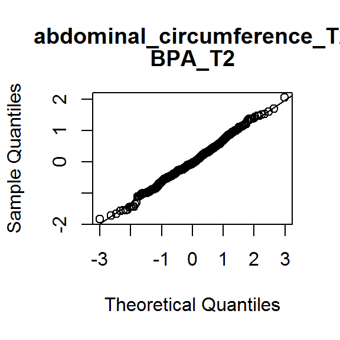

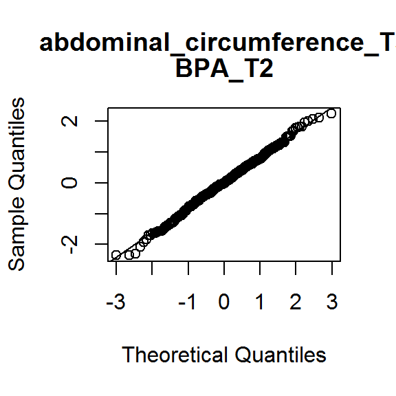

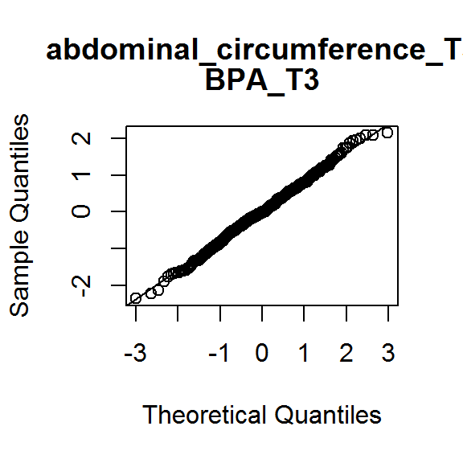

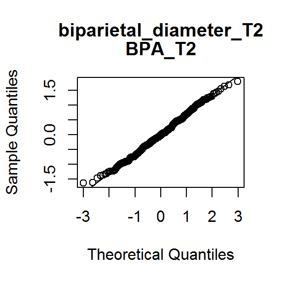

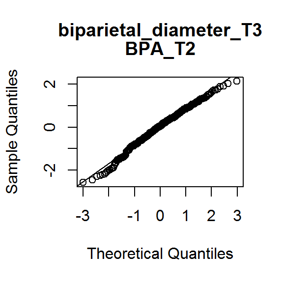

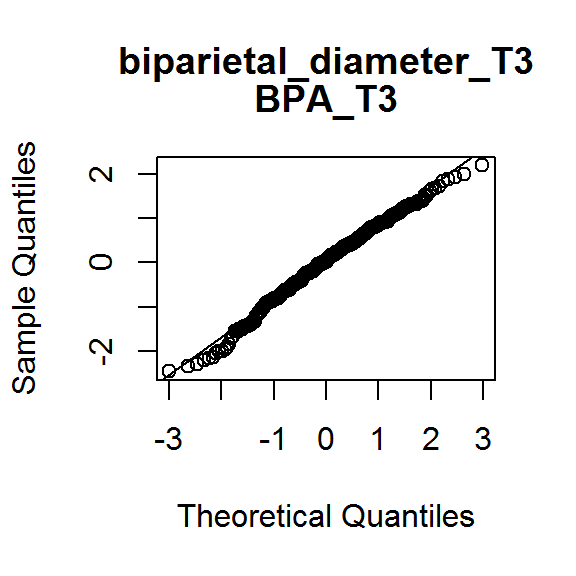

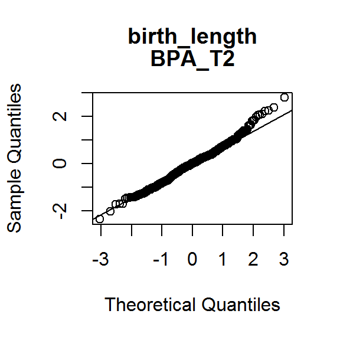

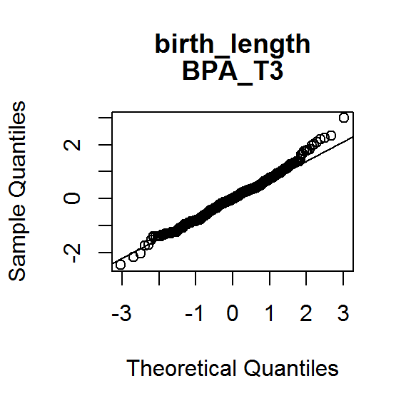

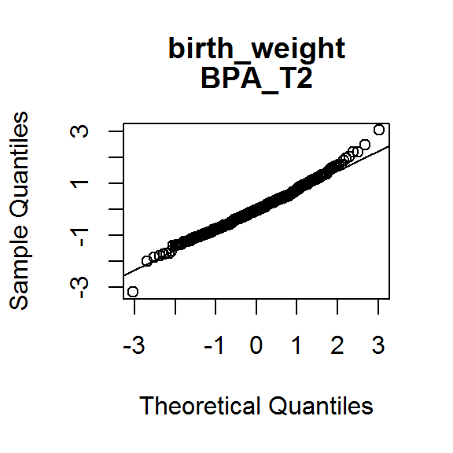

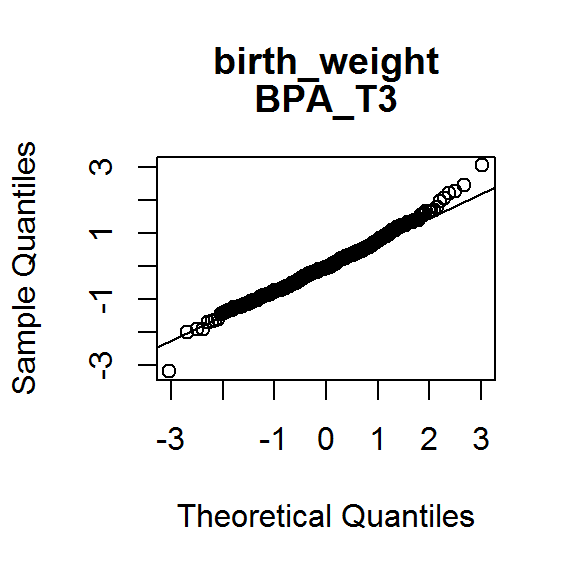

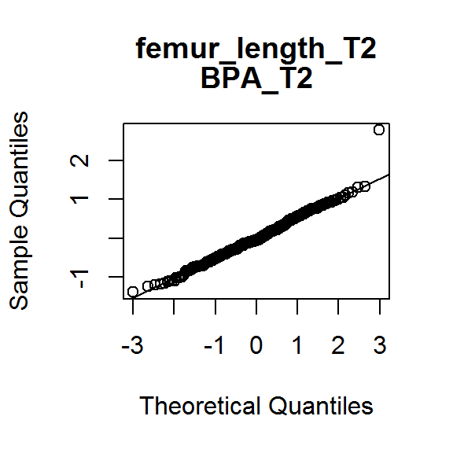

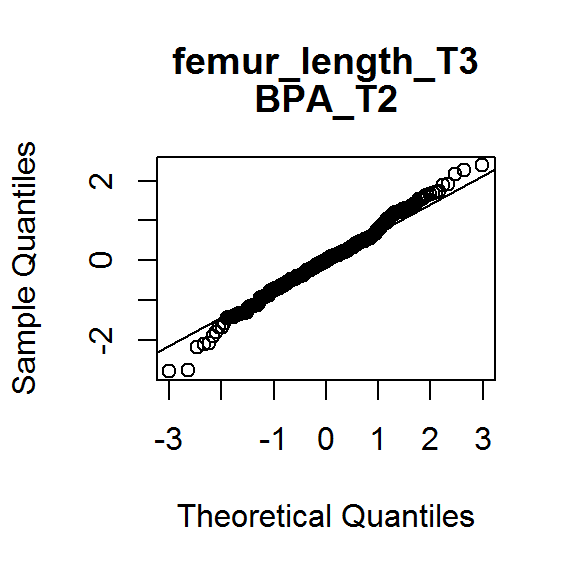

[6 more figures not shown]